# Identificando Interações em Experimentos Fatoriais

Professor: Cleanderson R. Fidelis

## Introdução

Nesta aula, aprenderemos a:

- Criar gráficos de interação para representar os efeitos de dois fatores em um experimento fatorial.
- Representar croquis experimentais usando o pacote AgroR.
- Analisar dados experimentais para verificar se há interação entre os fatores.

## Exemplo 1

Sejam os dados de um experimento, em blocos casualizados, no esquema fatorial $3 \times 3$, em que foram estudados os efeitos de **3 Peneiras comerciais**, associadas a **3 Densidades de plantio**, na produtividade do amendoim (*Arachis hypogaea L.*) variedade Tatu V53.

As **Peneiras comerciais (P)** e as **Densidades de plantio (D)** estudadas foram:

- $P_1$: peneira 18 (crivos circulares com diâmetro de 18/64 polegadas);
- $P_2$: peneira 20 (crivos circulares com diâmetro de 20/64 polegadas);
- $P_3$: peneira 22 (crivos circulares com diâmetro de 22/64 polegadas);
- $D_1$: 10 plantas por metro linear;
- $D_2$: 15 plantas por metro linear;
- $D_3$: 20 plantas por metro linear.

```r
# Caso 1: Experimento sem interação
# Conjunto de Dados
cat("### Caso 1: Experimento sem interação\n")
```

```
## ### Caso 1: Experimento sem interação
```

```r
dados_amendoim <- data.frame(
  Tratamentos = c("P1D1", "P1D2", "P1D3", "P2D1", "P2D2", "P2D3", "P3D1", "P3D2", "P3D3"),
  Peneira = rep(c("P1", "P2", "P3"), each = 3),
  Densidade = rep(c("D1", "D2", "D3"), times = 3),
  Blocos = paste("Bloco", rep(rep(1:3,3),3)),
  Producao = c(11.82, 12.34, 13.41, 6.97, 8.96, 8.48, 7.53, 6.71, 6.82,
               12.03, 14.08, 12.98, 10.26, 9.2, 9.66, 7.67, 7.87, 8.44,
               12.55, 12.13, 13.35, 9.02, 9.84, 8.50, 7.81, 9.49, 9.37)
)

print(dados_amendoim)
```

```
##    Tratamentos Peneira Densidade  Blocos Producao
## 1         P1D1      P1        D1 Bloco 1    11.82
## 2         P1D2      P1        D2 Bloco 2    12.34
## 3         P1D3      P1        D3 Bloco 3    13.41
## 4         P2D1      P2        D1 Bloco 1     6.97
## 5         P2D2      P2        D2 Bloco 2     8.96
## 6         P2D3      P2        D3 Bloco 3     8.48
## 7         P3D1      P3        D1 Bloco 1     7.53
## 8         P3D2      P3        D2 Bloco 2     6.71
## 9         P3D3      P3        D3 Bloco 3     6.82
## 10        P1D1      P1        D1 Bloco 1    12.03
## 11        P1D2      P1        D2 Bloco 2    14.08
## 12        P1D3      P1        D3 Bloco 3    12.98
## 13        P2D1      P2        D1 Bloco 1    10.26
## 14        P2D2      P2        D2 Bloco 2     9.20
## 15        P2D3      P2        D3 Bloco 3     9.66
## 16        P3D1      P3        D1 Bloco 1     7.67
## 17        P3D2      P3        D2 Bloco 2     7.87
## 18        P3D3      P3        D3 Bloco 3     8.44
## 19        P1D1      P1        D1 Bloco 1    12.55
## 20        P1D2      P1        D2 Bloco 2    12.13
## 21        P1D3      P1        D3 Bloco 3    13.35
## 22        P2D1      P2        D1 Bloco 1     9.02
## 23        P2D2      P2        D2 Bloco 2     9.84
## 24        P2D3      P2        D3 Bloco 3     8.50
## 25        P3D1      P3        D1 Bloco 1     7.81
## 26        P3D2      P3        D2 Bloco 2     9.49
## 27        P3D3      P3        D3 Bloco 3     9.37
```

## Croqui experimental

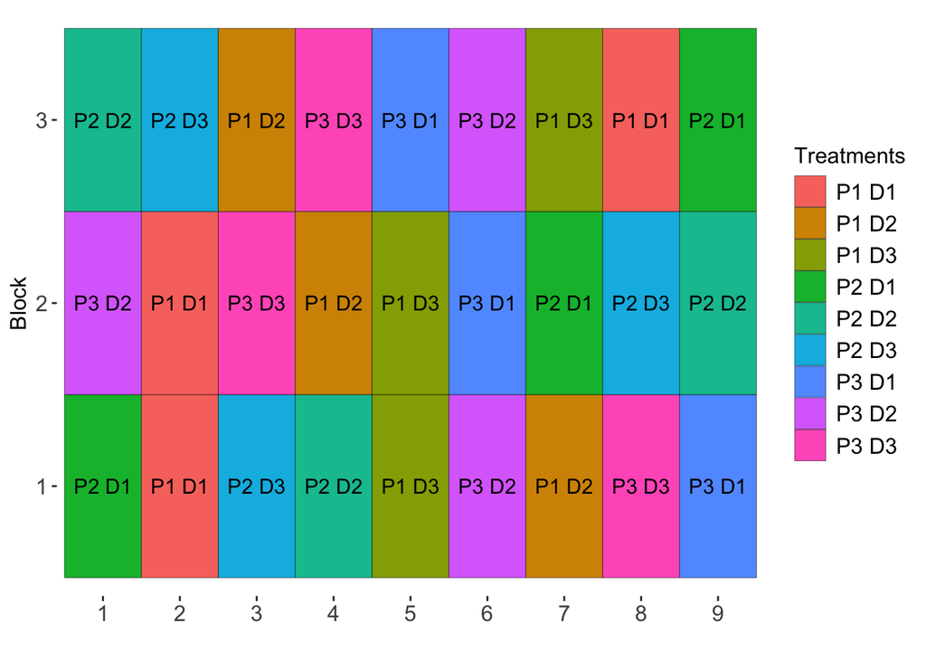

```r
# Croqui Experimental
library(AgroR)
sketch(trat=c("P1","P2","P3"),#paste("D",rep(1:3,3)),
       trat1=c("D1","D2","D3"),#paste("P",rep(1:3,3)),
       design = "fat2dbc",
       r=3)
```

## Construção do gráfico de interação

```r
# Calculando a produção média por tratamento
dados_media <- aggregate(Producao ~ Peneira + Densidade, data = dados_amendoim, FUN = mean)

# Visualizando os dados com médias
print(dados_media)
```

```
##   Peneira Densidade  Producao
## 1      P1        D1 12.133333
## 2      P2        D1  8.750000
## 3      P3        D1  7.670000
## 4      P1        D2 12.850000
## 5      P2        D2  9.333333
## 6      P3        D2  8.023333
## 7      P1        D3 13.246667
## 8      P2        D3  8.880000
## 9      P3        D3  8.210000
```

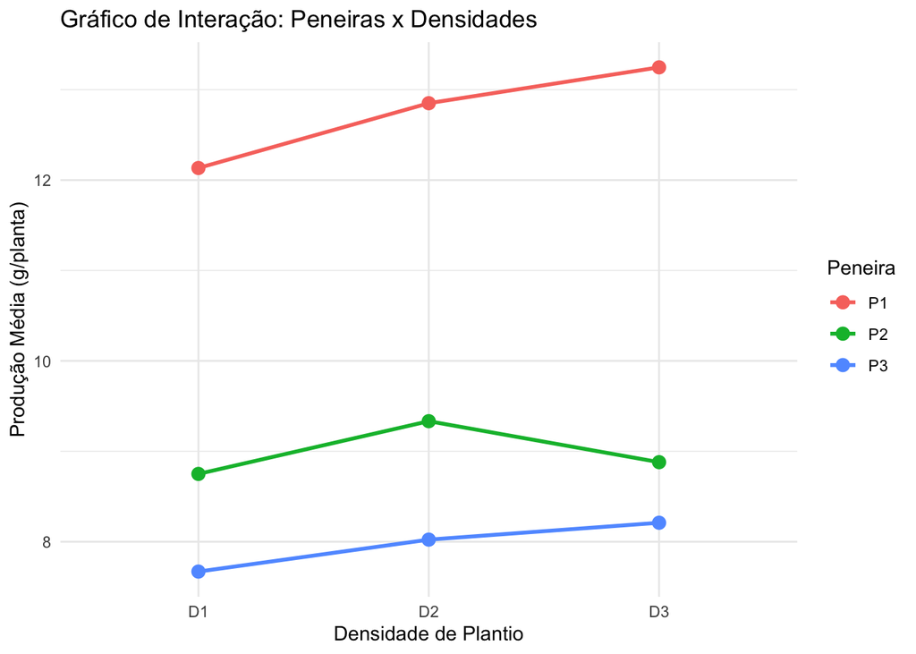

```r
# Gráfico de Interação com Produção Média
library(ggplot2)
ggplot(dados_media, aes(x = Densidade, y = Producao, color = Peneira, group = Peneira)) +
  geom_line(size = 1) +
  geom_point(size = 3) +
  labs(
    title = "Gráfico de Interação: Peneiras x Densidades",
    x = "Densidade de Plantio",
    y = "Produção Média (g/planta)"
  ) +
  theme_minimal()
```

As linhas paralelas indicam ausência de interação significativa entre os fatores.

## Exemplo 2

Considerando os dados de um experimento inteiramente casualizado, com **4 repetições** no esquema fatorial, para testar os efeitos de **3 Recipientes** ($R_1$, $R_2$ e $R_3$) e **2 Espécies de eucaliptos** ($E_1$ e $E_2$), na produção de mudas.

Quanto ao desenvolvimento das mudas, os recipientes e as espécies testados foram:

- $R_1$: saco plástico pequeno;
- $R_2$: saco plástico grande;
- $R_3$: laminado;
- $E_1$: *Eucalyptus citriodora*;
- $E_2$: *Eucalyptus grandis*.

```r
# Caso 2: Experimento com interação
# Conjunto de Dados
# Criando os dados do experimento
dados_eucalipto <- data.frame(
  Tratamentos = c("R1E1", "R1E2", "R2E1", "R2E2", "R3E1", "R3E2"),
  Recepiente = rep(c("R1", "R2", "R3"), each = 2),
  Especie = rep(c("E1", "E2"), times = 3),
  Altura = c(26.2, 24.8, 25.7, 19.6, 22.8, 19.8,
             26.0, 24.6, 26.3, 21.1, 19.4, 21.4,
             25.0, 26.7, 25.1, 19.0, 18.8, 22.8,
             25.4, 25.2, 26.4, 18.6, 19.2, 21.3)
)

# Visualizando os dados
print(dados_eucalipto)
```

```
##    Tratamentos Recepiente Especie Altura
## 1         R1E1         R1      E1   26.2
## 2         R1E2         R1      E2   24.8
## 3         R2E1         R2      E1   25.7
## 4         R2E2         R2      E2   19.6
## 5         R3E1         R3      E1   22.8
## 6         R3E2         R3      E2   19.8
## 7         R1E1         R1      E1   26.0
## 8         R1E2         R1      E2   24.6
## 9         R2E1         R2      E1   26.3
## 10        R2E2         R2      E2   21.1
## 11        R3E1         R3      E1   19.4
## 12        R3E2         R3      E2   21.4
## 13        R1E1         R1      E1   25.0
## 14        R1E2         R1      E2   26.7
## 15        R2E1         R2      E1   25.1
## 16        R2E2         R2      E2   19.0
## 17        R3E1         R3      E1   18.8
## 18        R3E2         R3      E2   22.8
## 19        R1E1         R1      E1   25.4
## 20        R1E2         R1      E2   25.2
## 21        R2E1         R2      E1   26.4
## 22        R2E2         R2      E2   18.6
## 23        R3E1         R3      E1   19.2
## 24        R3E2         R3      E2   21.3
```

## Croqui experimental

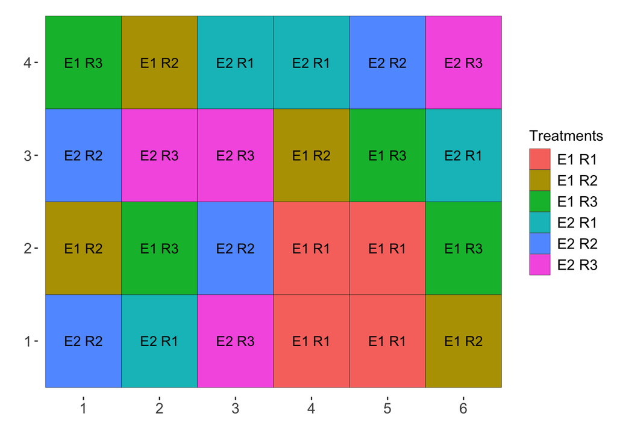

```r
# Croqui Experimental
sketch(trat=c("E1","E2"),
       trat1=c("R1","R2","R3"),
       design = "fat2dic",
       r=4)
```

## Gráfico para interação

```r
# Calculando a altura média por combinação de Recipiente e Espécie
library(dplyr)

dados_media <- dados_eucalipto %>%
  group_by(Recepiente, Especie) %>%
  summarise(Media_Altura = mean(Altura, na.rm = TRUE))

# Visualizando os dados com médias
print(dados_media)
```

```
## # A tibble: 6 × 3
## # Groups:   Recepiente [3]
##   Recepiente Especie Media_Altura
##   <chr>      <chr>          <dbl>
## 1 R1         E1              25.6
## 2 R1         E2              25.3
## 3 R2         E1              25.9
## 4 R2         E2              19.6
## 5 R3         E1              20.0
## 6 R3         E2              21.3
```

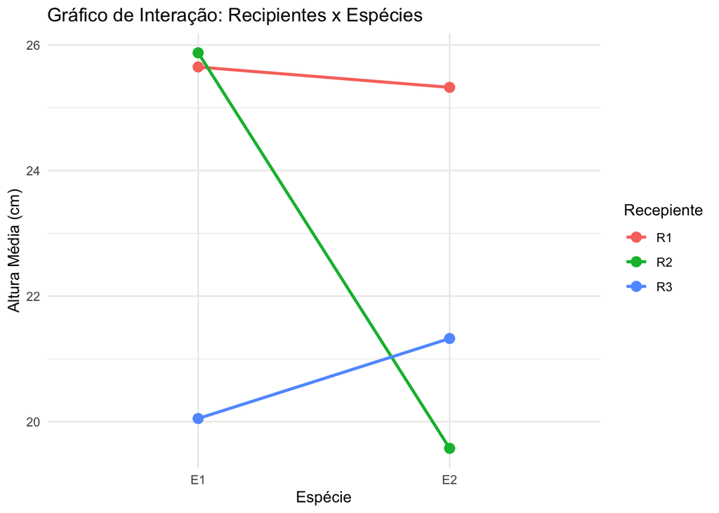

```r
# Gráfico de Interação com Alturas Médias
library(ggplot2)
ggplot(dados_media, aes(x = Especie, y = Media_Altura,
                        color = Recepiente,
                        group = Recepiente)) +
  geom_line(size = 1) +
  geom_point(size = 3) +
  labs(
    title = "Gráfico de Interação: Recipientes x Espécies",
    x = "Espécie",
    y = "Altura Média (cm)"
  ) +
  theme_minimal()
```

As linhas não paralelas (e, neste caso, cruzadas) indicam a presença de interação entre os fatores.

## Conclusões

- Experimentos fatoriais permitem analisar os efeitos de dois ou mais fatores simultaneamente.
- Gráficos de interação são ferramentas visuais úteis para identificar interações.
- O pacote AgroR facilita a criação de croquis experimentais para visualização do delineamento.